# Rapport

data-squad

2026-04-21

# Projet IF36 - DataSquad : Analyse des Données Olympiques (1896-2024)

## Présentation des données

Les données exploitées dans le cadre de ce projet proviennent d’un jeu de données extrait de la plateforme Kaggle, dans un format en `.csv`. Il contient les informations d’athlètes pendant les Jeux Olympiques de 1896 à 2024.

Nous avons choisi ce set de données car cela nous paraissait très intéressant, nous aimons bien le sport, extraire des statistiques de ce dataset peut-être très instructif. Nous avons vu un potentiel dans ce dataset, il nous permet de nous poser les bonnes questions, qui nous amèneront des graphiques et statistiques pertinents.

Nous avons donc une base de données de 8500 athlètes, avec des données sur 30 catégories. Ces variables couvrent à la fois les résultats sportifs des individus (répartition des médailles, records, valeur des résultats) et leurs profils biométriques et identitaires (pays d’origine, taille, poids, etc.).

## Types de données

| # | Nom de la colonne | Format donnée | Description | Type |
| --- | --- | --- | --- | --- |
| 1 | `athlete_id` | String | ID unique (format ATH-00001 à ATH-08500) | Discrète (Identifiant) |
| 2 | `athlete_name` | String | Nom complet (Prénom + Nom) | Discrète (Nominale) |
| 3 | `gender` | String | Sexe de l’athlète (Male/Female) | Discrète (Nominale) |
| 4 | `age` | Integer | Âge au moment de l’événement (15–42) | Discrète |
| 5 | `date_of_birth` | Date | Date de naissance (YYYY-MM-DD) | Continue (Temporelle) |
| 6 | `nationality` | String | Code CIO du pays sur 3 lettres (ex: USA, FRA) | Discrète (Nominale) |
| 7 | `country_name` | String | Nom complet du pays | Discrète (Nominale) |
| 8 | `sport` | String | Discipline (ex: Athlétisme, Natation) | Discrète (Nominale) |
| 9 | `event` | String | Épreuve spécifique (ex: 100m Sprint) | Discrète (Nominale) |
| 10 | `games_type` | String | Type de jeux (Summer / Winter) | Discrète (Nominale) |
| 11 | `year` | Integer | Année des JO (1896–2024) | Discrète (Temporelle) |
| 12 | `host_city` | String | Ville hôte des Jeux | Discrète (Nominale) |
| 13 | `team_or_individual` | String | Épreuve par équipe ou individuelle | Discrète (Nominale) |
| 14 | `medal` | String | Médaille : Gold, Silver, Bronze ou None | Discrète (Ordinale) |
| 15 | `result_value` | Float | Résultat chiffré (temps, distance, score) | Continue |
| 16 | `result_unit` | String | Unité du résultat (seconds, metres, points, kg) | Discrète (Nominale) |
| 17 | `total_olympics` | Integer | Nombre total de JO fréquentés (1–5) | Discrète |
| 18 | `total_medals_won` | Integer | Total de médailles en carrière | Discrète |
| 19 | `gold_medals` | Integer | Nombre de médailles d’or en carrière | Discrète |
| 20 | `silver_medals` | Integer | Nombre de médailles d’argent en carrière | Discrète |
| 21 | `bronze_medals` | Integer | Nombre de médailles de bronze en carrière | Discrète |
| 22 | `country_total_gold` | Integer | Total historique d’or du pays (jusqu’en 2024) | Discrète |
| 23 | `country_total_medals` | Integer | Total historique de médailles du pays | Discrète |
| 24 | `country_first_part` | Integer | Année de la première participation du pays | Discrète (Temporelle) |
| 25 | `country_best_rank` | Integer | Meilleur classement historique du pays | Discrète (Ordinale) |
| 26 | `is_record_holder` | String | Record : World Record / Olympic Record / No | Discrète (Nominale) |
| 27 | `coach_name` | String | Nom de l’entraîneur | Discrète (Nominale) |
| 28 | `height_cm` | Float | Taille de l’athlète en centimètres | Continue |
| 29 | `weight_kg` | Float | Poids de l’athlète en kilogrammes | Continue |
| 30 | `notes` | String | Contexte supplémentaire (ex: “Personal Best”) | Discrète (Texte libre) |

## Plan d’analyse

### Questions de recherche

- **Performance et Morphologie** : Est-ce que la taille/poids d’un athlète influence sa performance ?
- **Temporalité** : Quelles sont les saisons qui sont marquées par un grand nombre de compétitions ?
- **Succès national** : Quels pays remportent le plus de compétitions ?
- **Genre** : Y’a-t-il un genre mis en avant plus qu’un autre ?
- **Représentativité** : Quelles sont les nationalités les plus / moins représentées ?

### Interrogations et objectifs

Notre analyse gravite autour d’une problématique centrale : **L’influence de la morphologie (taille et poids) sur la performance athlétique.** Nous cherchons à déterminer si des caractéristiques physiques spécifiques constituent un avantage déterminant pour l’obtention d’une médaille ou d’un record.

**Objectifs secondaires :** * Existe-t-il une “taille idéale” par discipline sportive ? * Le rapport poids/taille (IMC) est-il plus corrélé à la performance que la taille seule ? * Cette influence morphologique a-t-elle évolué entre les premiers Jeux Olympiques et les éditions récentes (spécialisation des corps) ?

### Informations attendues

Nous espérons identifier des clusters d’athlètes performants par sport. Par exemple, nous anticipons une corrélation positive forte entre la taille et la performance en basketball ou en natation, tandis qu’elle pourrait être négative ou inexistante en gymnastique ou en équitation.

### Variables comparées et méthodes

Pour valider nos hypothèses, nous allons croiser les variables suivantes : 1. **Taille (height_cm) vs Performance (result_value)** : Utilisation de nuages de points pour visualiser la dispersion et calcul du coefficient de corrélation de Pearson ($r$). 2. **Poids (weight_kg) vs Sport (sport)** : Comparaison des distributions via des boîtes à moustaches (boxplots) pour voir la variabilité du poids selon la discipline. 3. **Médaille (medal) vs Morphologie** : Analyse par groupes pour voir si les médaillés d’or présentent des caractéristiques physiques distinctes du reste des participants.

## Défis et limites potentiels

- **Hétérogénéité des unités** : La variable `result_value` mélange des secondes, des mètres et des points. Il faudra normaliser ces données ou filtrer l’analyse sport par sport.
- **Données manquantes** : Les données historiques comportent souvent des valeurs de poids ou de taille manquantes, ce qui pourrait biaiser l’analyse temporelle.
- **Variables confondantes** : La performance dépend aussi de l’âge, de l’expérience (`total_olympics`) et des infrastructures du pays d’origine.

# Rapport de l’étude de base de données :

# Question 1: Quels sont les pays qui ont accumulé le plus de médailles d’or au cours de l’histoire des Jeux Olympiques ?

Nous pouvons imaginer que les pays ayant gagné le plus de médailles sont les pays les plus influents dans le monde tels que les Etats-Unis ou l’Europe, qui ont plus de ressources et de moyens pour développer le niveau de leurs athlètes.

Avant de débuter l’analyse, une étape de préparation a été nécessaire sur le jeu de données. Nous avons notamment dû gérer les valeurs manquantes dans les colonnes de médailles en utilisant l’argument “na.rm = TRUE”, afin d’éviter que des données non renseignées ne faussent les calculs de sommes globales par pays.

Prendre tous les pays ferait un graphique non lisible, nous avons donc dû choisir de ne prendre que les 15 pays ayant gagné le plus de médailles.

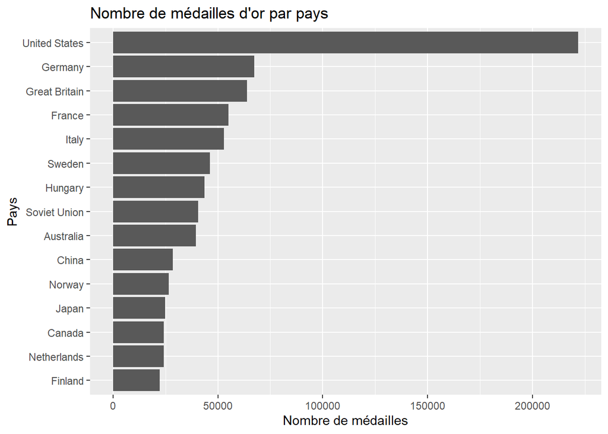

# Question 2 : Quelles sont les nationalités les plus / moins représentées ?

L’objectif de cette partie est d’analyser la représentativité des nationalités dans le dataset des athlètes olympiques.

## Graphe 1 — Pays les plus représentés

### Choix du graphique

Nous avons choisi un diagramme en barres pour représenter les nationalités les plus présentes dans le dataset. Ce type de graphique est particulièrement adapté à la comparaison de valeurs quantitatives entre différentes catégories. Le choix d’un Top 15 permet d’obtenir une vision suffisamment large des pays dominants tout en conservant une bonne lisibilité.

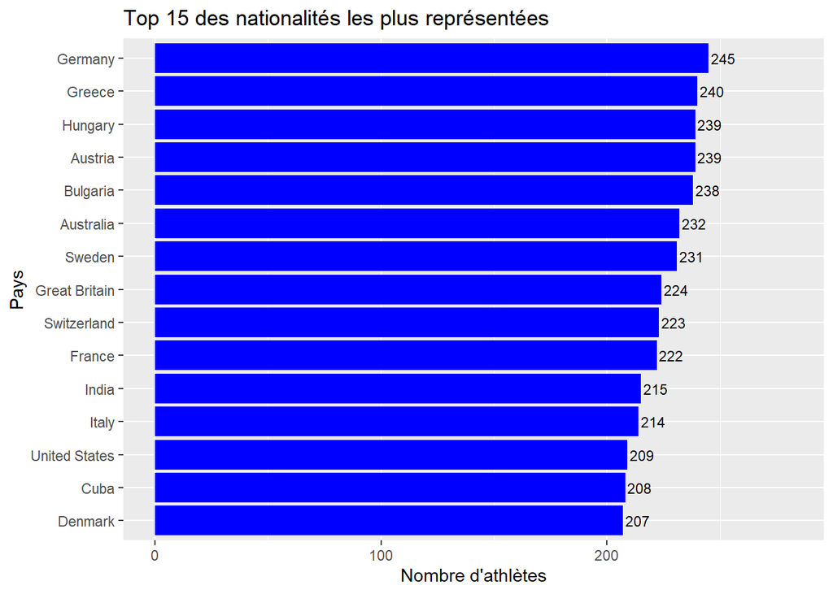

## Interprétation

Ce graphique met en évidence les nationalités les plus représentées dans le dataset. Chaque barre correspond à un pays, et sa longueur indique le nombre d’athlètes.

Cela montre une forte concentration des données autour de quelques nationalités dominantes. Cette situation peut s’expliquer par la taille des délégations, la régularité de participation aux Jeux olympiques ou encore les ressources sportives plus importantes de certains pays.

## Graphe 2 — Pays les moins représentés

### Choix du graphique

Nous avons également choisi un diagramme en barres pour les pays les moins représentés afin de garder une cohérence visuelle avec le premier graphique. Ce choix facilite la comparaison entre les extrêmes du dataset.

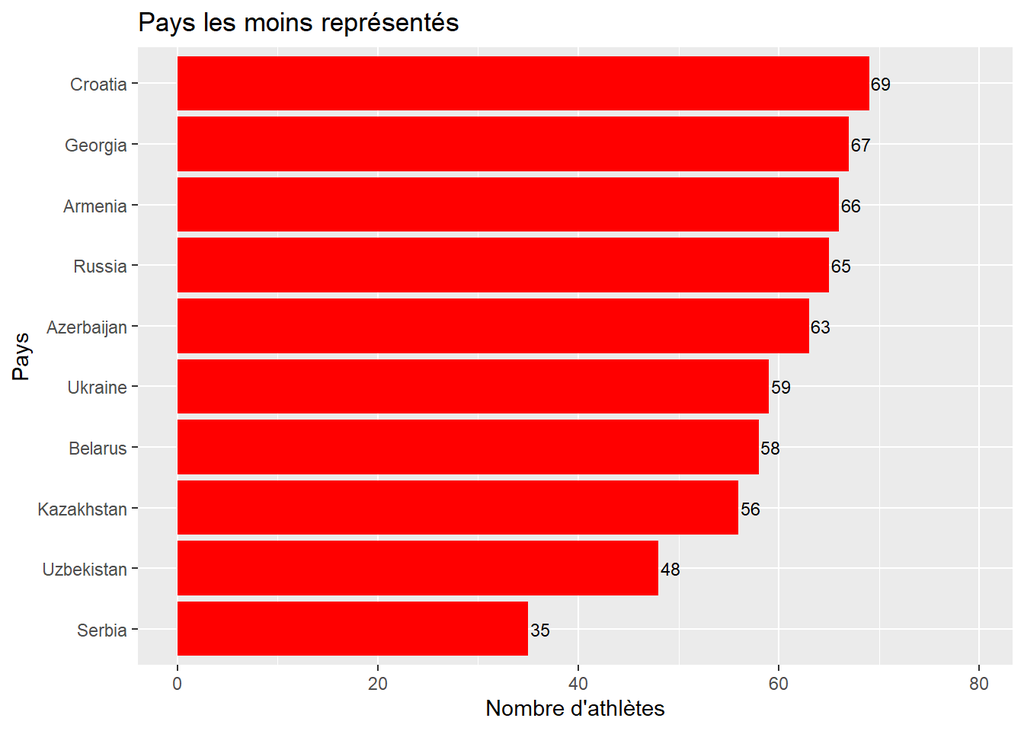

## Interprétation

Ce graphique met en évidence les nationalités les moins représentées dans le dataset. Contrairement au premier graphique, les effectifs observés ici sont très faibles et relativement proches les uns des autres.

Cela signifie qu’un grand nombre de pays occupent une place très marginale dans les données. Cette faible représentation peut s’expliquer par une participation plus récente, une présence limitée à certaines disciplines ou des moyens sportifs plus faibles.

Ce graphique complète donc le premier en montrant que la représentativité des nationalités n’est pas uniforme : quelques pays dominent, tandis que beaucoup d’autres sont très peu présents.

## Graphe 3 — Comparaison

### Choix du graphique

Ce graphique a été choisi pour comparer directement les extrêmes du dataset, c’est-à-dire les pays les plus représentés et les moins représentés. Le fait de les regrouper dans un même espace visuel permet de mettre en évidence immédiatement l’écart entre les deux groupes.

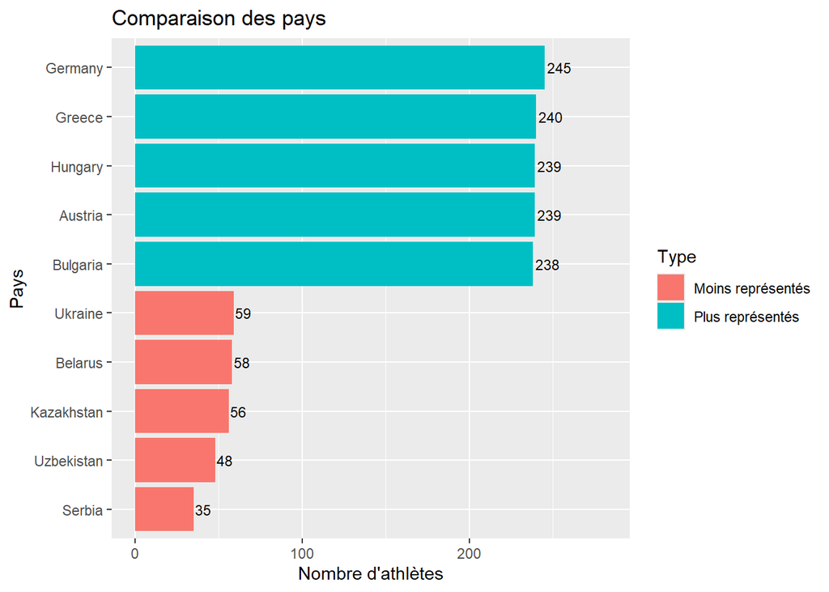

## Interprétation

Ce graphique montre clairement l’écart entre les pays les plus représentés et les pays les moins représentés. Les différences de hauteur entre les barres sont très importantes, ce qui rend la comparaison immédiate.

On constate que les pays les plus représentés possèdent un nombre d’athlètes largement supérieur à celui des pays les moins représentés. Cette différence met en évidence une forte inégalité de représentativité dans le dataset.

Ce graphique permet donc de synthétiser les résultats des deux premiers graphes : la distribution des nationalités est fortement déséquilibrée, avec une concentration importante autour de quelques pays.

### Conclusion pour Représentativité

L’analyse de ces trois graphiques montre que la représentativité des nationalités dans le dataset est très inégale. Quelques pays concentrent une grande partie des athlètes, tandis qu’un grand nombre de nationalités sont faiblement représentées.

Le premier graphique permet d’identifier les pays dominants avec des valeurs précises. Le deuxième montre que de nombreux pays occupent une place marginale. Enfin, le troisième met directement en évidence l’écart entre ces deux groupes. L’ensemble confirme donc une structure déséquilibrée de la répartition des nationalités.

# Question 3: Est-ce que la taille/poids d’un athlète influence sa performance ?

Cette partie analyse si la corpulence d’un athlète (mesurée par l’Indice de Masse Corporelle - IMC) constitue un avantage déterminant pour ses performances.

## Force de l’influence de l’IMC par discipline

Ce graphique permet d’identifier les disciplines où la corpulence a l’influence la plus forte sur le résultat (chrono, points, distance).

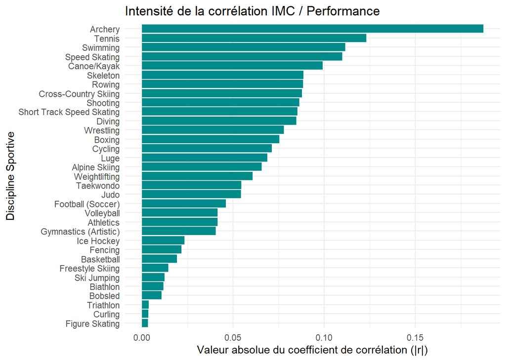

## Zoom sur les sports clés

Pour comprendre l’impact réel, nous isolons deux sports aux tendances opposées.

### Archery (Tir à l’arc) : Une corrélation positive

En tir à l’arc, le résultat est en **points** (plus c’est haut, mieux c’est).

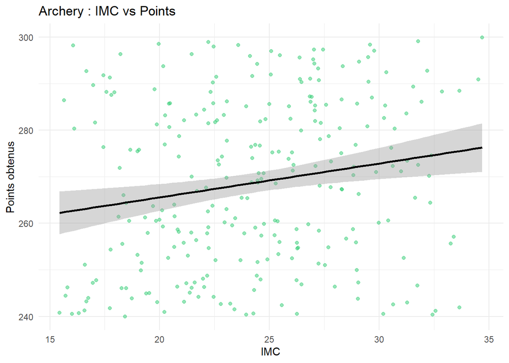

**Interprétation :** On observe une pente montante. Cela signifie qu’un IMC plus élevé est globalement associé à un meilleur score en points. Une plus grande masse corporelle pourrait offrir une meilleure assise et stabilité face au vent ou lors de la tension de l’arc.

### Swimming (Natation) : Une corrélation négative

En natation, le résultat est souvent en **secondes** (plus c’est bas, mieux c’est).

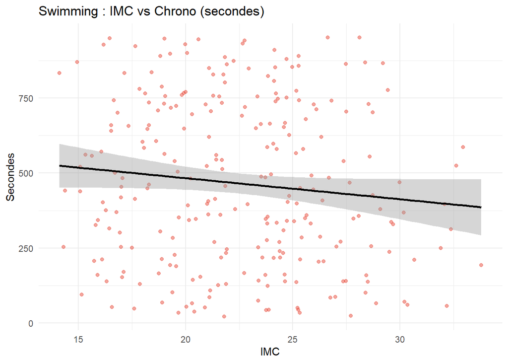

**Interprétation :** La pente est descendante. Comme le résultat est exprimé en secondes, une baisse du temps signifie une amélioration. On peut en conclure qu’un IMC plus élevé est souvent un avantage pour la propulsion et la puissance dans l’eau chez les nageurs Olympiques.

### Conclusion sur la morphologie

# Question 4 : Y a-t-il un genre plus représenté que l’autre ?

Ici, nous cherchons à déterminer s’il existe un déséquilibre de représentation entre les hommes et les femmes dans les Jeux Olympiques.

Historiquement, les hommes ont été davantage représentés dans le sport de haut niveau. Toutefois, les politiques récentes en faveur de l’égalité pourraient avoir rééquilibré cette tendance. Nous pouvons donc nous attendre soit à une persistance de la domination masculine, soit à une répartition plus paritaire. Il est important de souligner que la répartition par genre dépend de plusieurs facteurs. Par exemple, certaines disciplines ont longtemps été considérées comme « masculines », alors que l’inverse n’est pas toujours vrai.

Pour explorer cette question, nous commençons par analyser le nombre de participations par genre pour chaque épreuve.

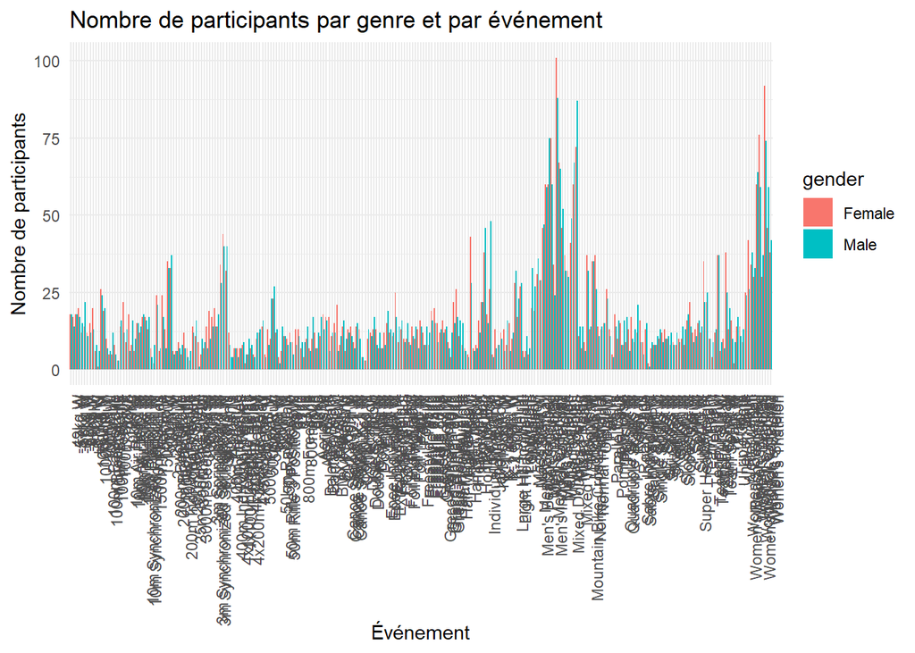

Ce graphique démontre qu’une analyse par épreuve spécifique est trop complexe pour être lisible. Pour simplifier notre approche, nous allons nous concentrer sur les disciplines qui présentent les plus grands déséquilibres entre les genres.

### Les 8 sports avec les plus fortes disparités de genre

Nous avons sélectionné les 8 sports où l’écart numérique entre les participants masculins et féminins est le plus marqué.

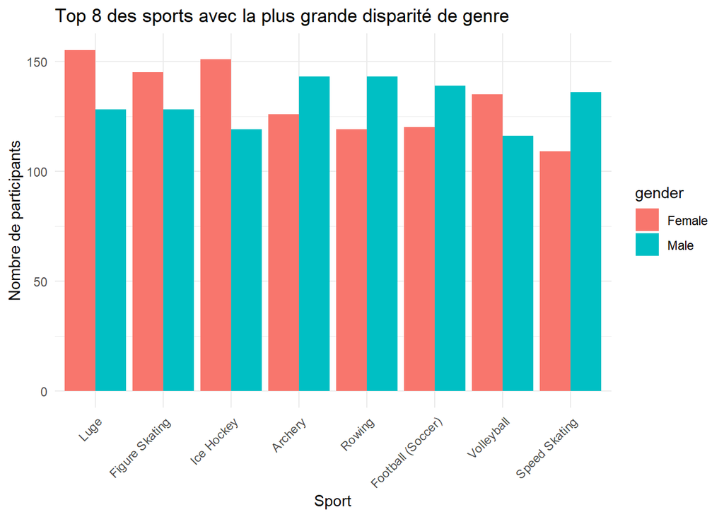

Ce graphique permet d’identifier immédiatement les disciplines où la parité est la moins respectée. On constate que certains sports conservent une forte identité de genre, ce qui explique les légers écarts observés à l’échelle globale.

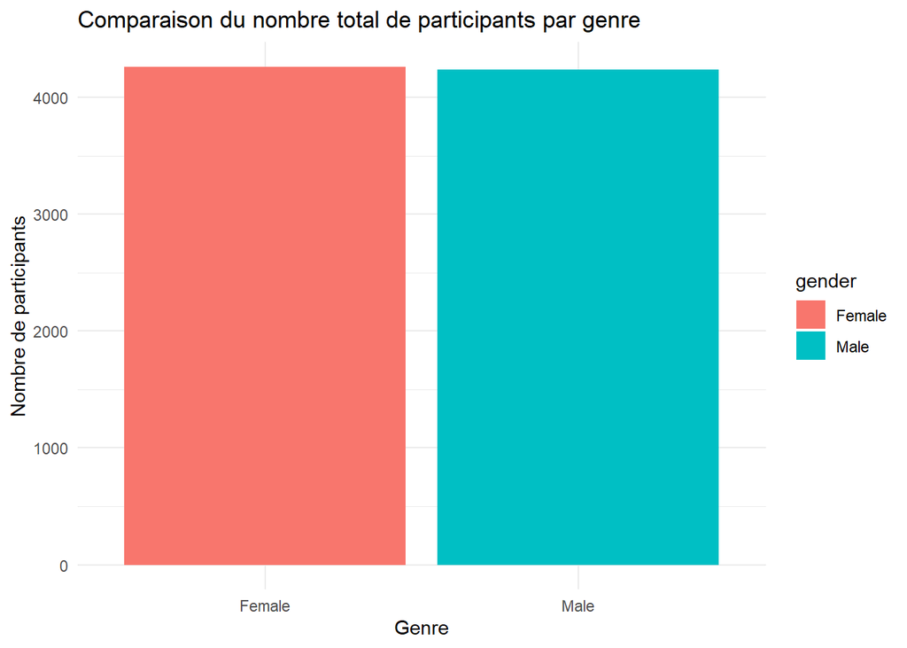

Afin d’obtenir une vision d’ensemble, nous comparons le nombre total de participations par genre.

Les résultats montrent une répartition très équilibrée :

- **Femmes** : 4 263 participations
- **Hommes** : 4 237 participations

Ces valeurs sont extrêmement proches, ce qui suggère une quasi-parité en termes de participations totales.

Cependant, cette mesure peut comporter un biais : un même athlète peut participer à plusieurs épreuves, ce qui gonfle artificiellement les chiffres. Il est donc nécessaire d’affiner l’analyse.

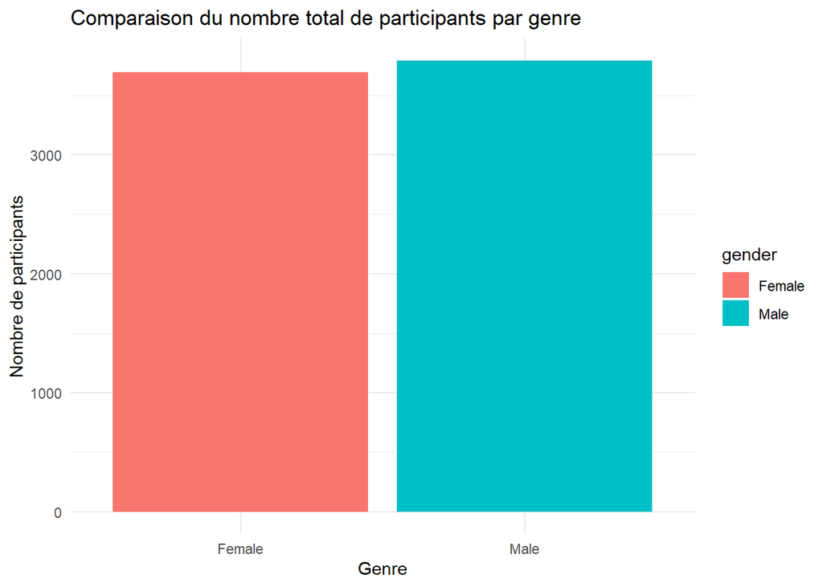

Pour lever ce biais, nous comptons désormais le nombre d’athlètes uniques par genre. Les résultats sont les suivants :

- **Femmes** : 3 696 athlètes
- **Hommes** : 3 795 athlètes

Cette fois, un léger avantage masculin apparaît. Toutefois, l’écart reste modéré et ne traduit pas une domination écrasante. Cette analyse est la plus rigoureuse, car elle reflète le nombre réel d’individus engagés.

### Conclusion sur la parité de genre

L’ensemble de l’analyse permet de répondre à notre problématique initiale : aucun genre n’est massivement privilégié dans ce jeu de données.

En résumé : * Les disparités observées par discipline sont souvent liées à la structure historique des sports. * Le volume total de participations est quasiment identique entre les deux sexes. * Le nombre d’athlètes uniques révèle une légère prédominance masculine, mais la tendance globale penche vers la parité.

Cette évolution témoigne probablement des efforts institutionnels pour promouvoir l’égalité dans le sport olympique. Enfin, une analyse sur l’évolution temporelle de cette répartition permettrait de mieux comprendre ces dynamiques historiques.

# Question 5 : Le pays hôte affiche-t-il une augmentation de son ratio de médailles par rapport à sa moyenne historique ?

Nous cherchons, dans cette question, a chercher si il y a un nombre plus élevé de médailles pour les pays hôte des Jeux Olympiques, l’année où ils sont hôtes, par rapport a la valeur globale des médailles de ce pays.

Notre hypothèse est que pendant les années où un pays est hôte, le pays surperforme grâce à l’aide mentale qu’apporte le soutien du public, le support mental du fait de vouloir performer dans son pays, ainsi que les investissements massifs entrainés par la présence des Jeux Olympiques.

Pour répondre à cette question, nous allons utiliser un bar chart, qui nous montrera une comparaison entre la moyenne du nombre de médailles qui les pays ont pendant les années des Jeux Olympiques, et le nombre de médailles que le pays gagne quand il est hôte des Jeux Olympiques. La complication de cette question était de relier les valeurs de la variable host_city avec la variable nationality, ce qui a été fait en utilisant la fonction tibble::tribble.

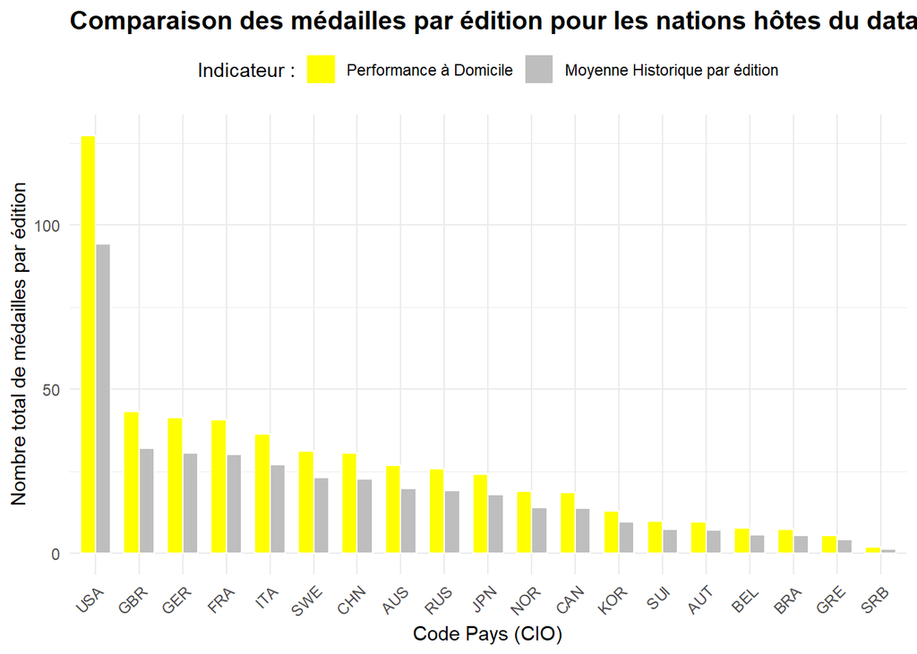

#### Interprétation :

On peut donc voir dans ce graphique qu’il y a pour chaque pays analysé, la barre des années où le pays est hôte est plus haute, à peu près de 30 % en moyenne, que la moyenne des pays pendant les Jeux Olympiques. On peut donc en comprendre que notre hypothèse est validée, il y a bien un avantage à domicile, qui fait qu’il y a plus de médailles les années ou le pays est hôte des Jeux Olympiques.

# Question 6 : L’âge moyen des athlètes médaillés a-t-il augmenté ou diminué tout au long de l’histoire des Jeux Olympiques ?

Nous cherchons donc a regarder l’âge médian des médaillés dans les Jeux Olympiques, pour pouvoir comparer entre les années, pour voir si il y a des changements notables.

Notre hypothèse est que l’âge moyen pourrait augmenter en fonction de l’année, grâce aux avancements de la médecine et de la technologie, qui permettraient aux athlètes d’avoir une carière plus longue, et de rester au maximum de leurs capacités pendant plus longtemps.

Pour cela nous allons donc faire un line chart, pour pouvoir avoir l’évolution, et une courbe de tendance globale, pour pouvoir voir une plus grande variété de résultats.

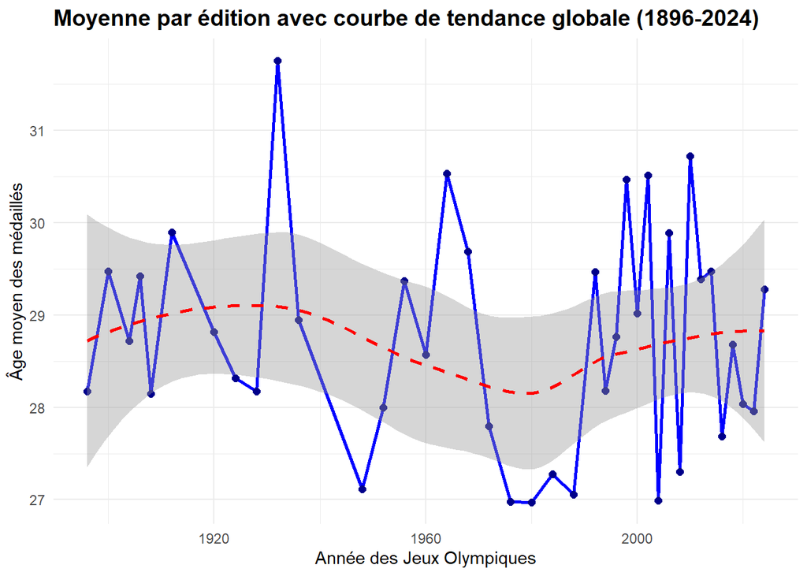

#### Interprétation :

On peut donc en comprendre que les technologies et la médecine n’ont pas un effet assez fort pour influencer l’âge moyen des médaillés.

# Question 7 : Existe-t-il une différence en terme de poids, enre les athlètes participant aux Jeux D’été, et ceux des Jeux d’hiver ?

Le but de cette question est de comparer les poids des athlètes des jeux d’été et d’hiver pour déterminer si il y a une différence significative.

Notre hypothèse est qu’il y aura une petite différence de poids, car les sports de Jeux d’hiver se basent sur l’inertie, ce qui pourrait nécessiter une masse supérieure, même si on suppose qu’il y aura des extrèmes plus importants pour l’été, avec par exemple des sport de lancer, qui ne nécessitent pas d’être plus léger.

Pour répondre à cette question, nous allons utiliser un graphique en violon, qui permet de bien voir la distribution, en utilisant aussi des lignes pour voir les différents quantiles, et de pouvoir voir les extrêmes.

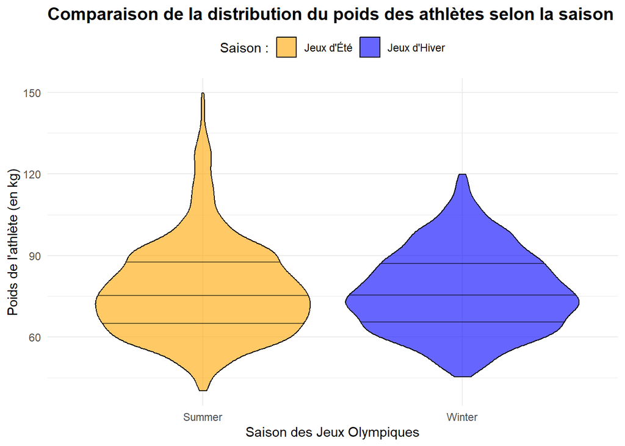

#### Interprétation :

On peut voir que la distribution de poids est très similiare sur les deux saisons, ce qui ne valide pas notre hypothèse. La forme des violons est presque identique, et les médianes sont au même niveau, ce qui montre que la moyenne des profils sur les deux saisons est similaire. Mais une partie de notre hypothèse est bonne quand même, car on voit des profils beaucoup plus lourds sur les Jeux d’été, qui peuvent venir des sports de lancer, ou de combats, ou d’autres sports, qui ne sont pas présents aux Jeux d’hiver.

# Question 8 : Quelles sont les disciplines sportives qui comptent le plus grand nombre d’athlètes enregistrés ?

Le but de cette question est de voir quels sont les sports avec le plus d’athèles, pour voir si certains sports qui ont une plus grande base de joueur en dehors des Jeux Olympiques, ont aussi le plus d’athlètes dans les Jeux Olympiques.

Notre hypothèse est que les sport les plus “gros” et les plus suivis, tels que la natation ou l’athlétisme, auront le plus d’athlètes.

Pour répondre à cette question, nous allons utiliser un diagramme en barres horizontales, en triant par odre décroissant.

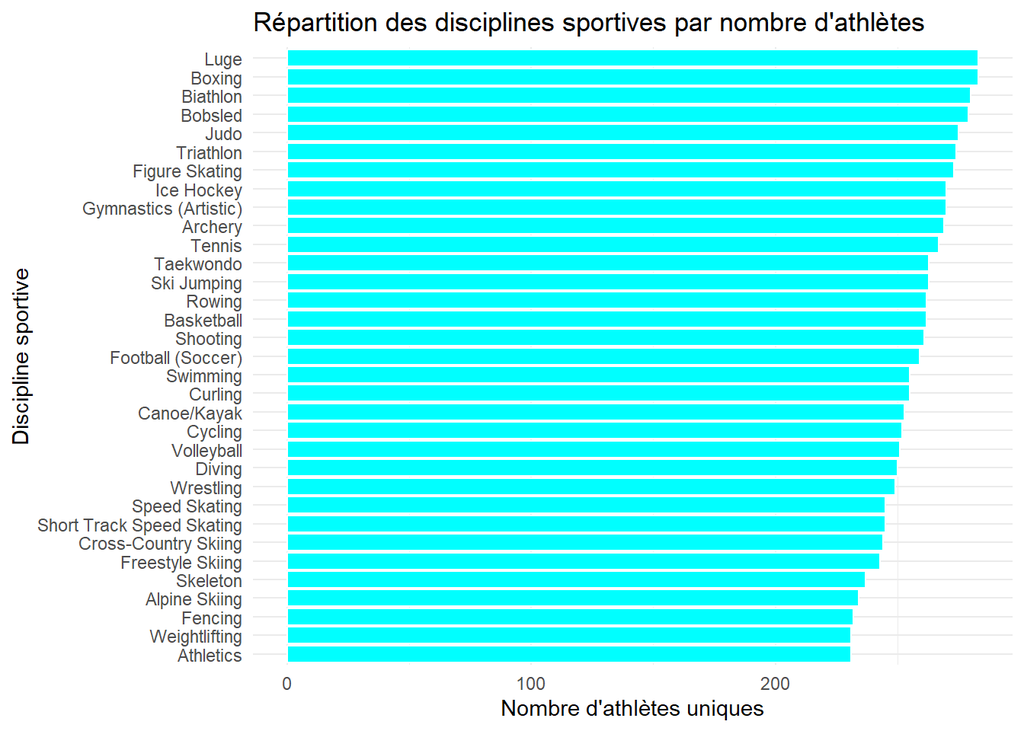

#### Interprétation :

Dans ce graphique, le nom des sports est difficilement lisilble, nous allons donc en faire un second avec seuelement le top 5 des sports, mais on peut quand même voir avec ce graphique que la différence entre le nombre d’athlètes entre les plus représentés et les moins représentés n’est pas énorme, tous les sports ayant entre 200 et 300 athlètes.

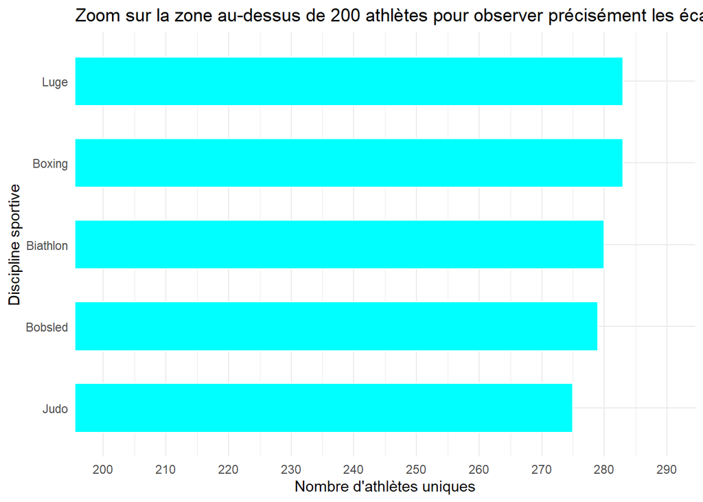

#### Interprétation :

On peut voir que les 5 sports avec le plus d’athlètes ne sont pas les sports les plsu “gros” auxquels ont pensait pendant notre hypothèse, mais ce sont d’autres sports. Ces 5 sport ont seulement une différence de 10 athlètes, ce qui est très peu.

On peu donc en tirer que soit notre jeu de données n’est pas une liste de juste tous les athlètes, mais est un échantillon choisit de manière équilibrée pour avoir une représentativité équivalente pour tous les sports, soit il y a plus d’athlètes dans ces 5 sports, que dans les “grands” sports comme la natation ou l’athétisme.

# Question 9 : Corrélation entre expérience olympique et succès

**Question :** Existe-t-il un “pic d’efficacité” en fonction du nombre de participations (`total_olympics_attended`) ? Est-on plus susceptible de gagner l’or à sa 1ère, 2ème ou 3ème participation ?

**Hypothèse :** La performance maximale (médaille d’or) survient plus souvent lors de la deuxième participation (équilibre entre jeunesse et expérience).

Pour répondre à cette question sans être biaisé par le fait qu’il y a beaucoup plus d’athlètes réalisant une seule participation par rapport à ceux en cumulant plusieurs, nous allons créer une **Heatmap (Carte de chaleur)**. Elle affichera la proportion (en pourcentage) de chaque type de résultat selon le nombre de participations.

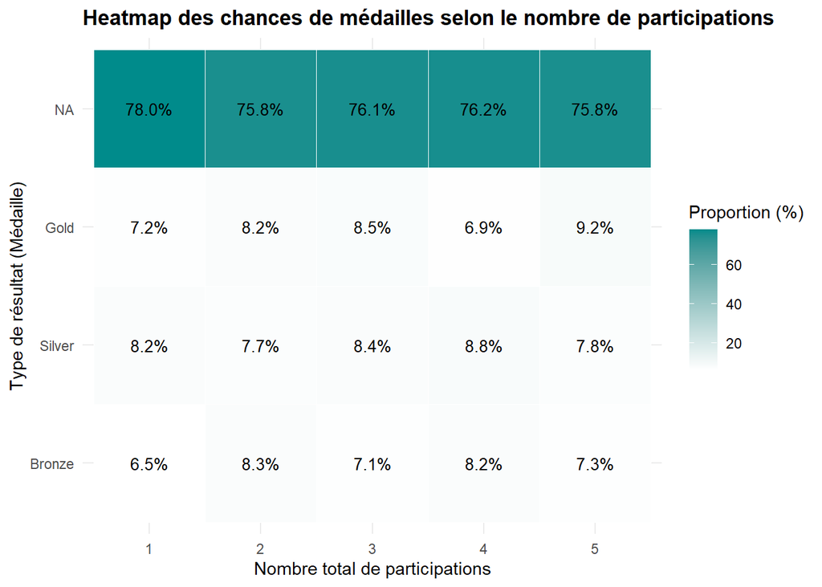

# Question 10 : L’efficacité des délégations (Ratio Participation/Succès)

**Question :** Quelles sont les nationalités qui possèdent le meilleur “taux de transformation” (nombre de médailles remportées divisé par le nombre d’athlètes uniques envoyés) ?

**Hypothèse :** Les grandes nations (avec un grand nombre d’athlètes) remportent le plus grand volume de médailles, mais certaines plus petites délégations ciblées affichent un taux d’efficacité (médailles par athlète) exceptionnel.

Pour répondre à cette question, nous allons croiser le nombre d’athlètes uniques envoyés par pays avec le nombre total de médailles obtenues. Le graphique proposé est un **Scatter Plot (nuage de points)** où : - L’abscisse (X) représente le nombre d’athlètes uniques envoyés par pays. - L’ordonnée (Y) représente le nombre total de médailles remportées. - La taille et la couleur des points reflètent le **taux de transformation** (le pourcentage d’athlètes de la délégation repartant avec une médaille).

Nous filtrons les pays ayant envoyé moins de 10 athlètes pour éviter les cas extrêmes de petites délégations qui fausseraient les statistiques d’efficacité globale.

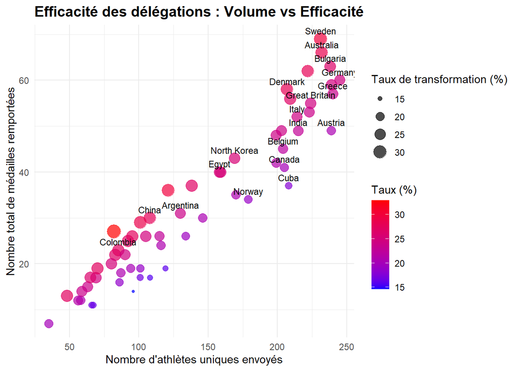

#### Interprétation :

Le nuage de points permet de distinguer deux stratégies ou dynamiques différentes chez les nations olympiques : 1. **Les géants olympiques :** Situés en haut à droite (grand nombre d’athlètes et grand nombre de médailles). Ces pays envoient d’immenses délégations et convertissent une part significative de leurs athlètes en médaillés. 2. **Les délégations ultra-efficaces :** Situées plus haut par rapport à leur position horizontale (les points rouges/chauds). Ces pays ont un taux de transformation élevé, ce qui signifie qu’une grande partie des athlètes qu’ils envoient réussissent à décrocher une médaille.

Ce graphique illustre parfaitement le compromis entre la quantité d’athlètes engagés et l’optimisation des performances par athlète individuel.

# Question 11 : L’évolution morphologique temporelle (La spécialisation des corps)

Nous avons vu précédemment que l’IMC impacte la performance aujourd’hui. Mais est-ce que cette optimisation a toujours existé ? Les athlètes sont-ils devenus physiquement plus “extrêmes” au fil des décennies dans certaines disciplines ?

**Hypothèse :** Avec la professionnalisation du sport, le physique des athlètes s’est ultra-spécialisé. La taille moyenne des basketteurs a augmenté, tandis que celle des gymnastes a diminué par rapport aux premières éditions des Jeux Olympiques.

Pour valider cette hypothèse, nous croisons les variables d’année, de taille et de discipline pour deux sports aux besoins morphologiques opposés : le Basketball et la Gymnastique Artistique.

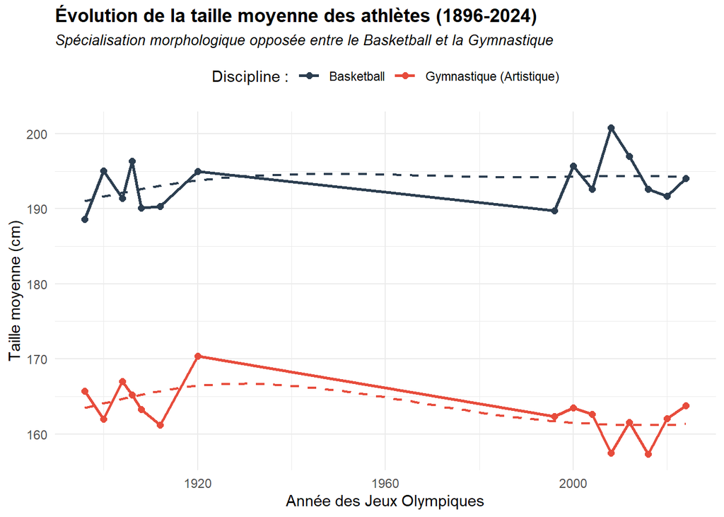

#### Interprétation :

Le graphique confirme notre hypothèse d’ultra-spécialisation des corps, visible à travers la divergence progressive des deux courbes de tendance (en pointillés).

Malgré un creux de données entre 1930 et 1980 pour ces disciplines, l’évolution sur plus d’un siècle est marquée : 1. **Basketball :** La courbe de tendance montre une augmentation globale, passant d’environ 1m91 à plus de 1m94. Sur les éditions récentes (après 2000), on observe même un pic au-dessus de 2 mètres en moyenne, prouvant que les profils de très grande taille sont toujours plus recherchés. 2. **Gymnastique (Artistique) :** À l’inverse, la tendance est à la baisse. Partant d’environ 1m65 au début du siècle dernier, la taille moyenne diminue pour s’établir autour de 1m61 de nos jours, avec des creux récents sous la barre des 1m60. Un centre de gravité plus bas facilite en effet l’exécution de figures acrobatiques complexes.

Cette évolution opposée met en évidence que les caractéristiques physiques ne sont pas dues au hasard : elles s’optimisent et se spécialisent pour répondre de plus en plus précisément aux exigences spécifiques de chaque discipline de haut niveau.

# Question 12 : Le phénomène de l’Effet d’Âge Relatif (Relative Age Effect)

Ce phénomène est un grand classique de la data science sportive. Il s’agit de vérifier si le mois de naissance influence les chances de devenir un athlète olympique.

**Hypothèse :** Les athlètes nés en début d’année (janvier, février, mars) sont surreprésentés. Dans les catégories de jeunes, ils sont physiquement plus matures de quelques mois que ceux nés en fin d’année, ce qui les place plus facilement dans les filières d’élite (le fameux “Relative Age Effect”).

Pour vérifier cela, nous allons extraire le mois de naissance de chaque athlète et observer la distribution comparée à une répartition théorique parfaite (environ 8.33% par mois).

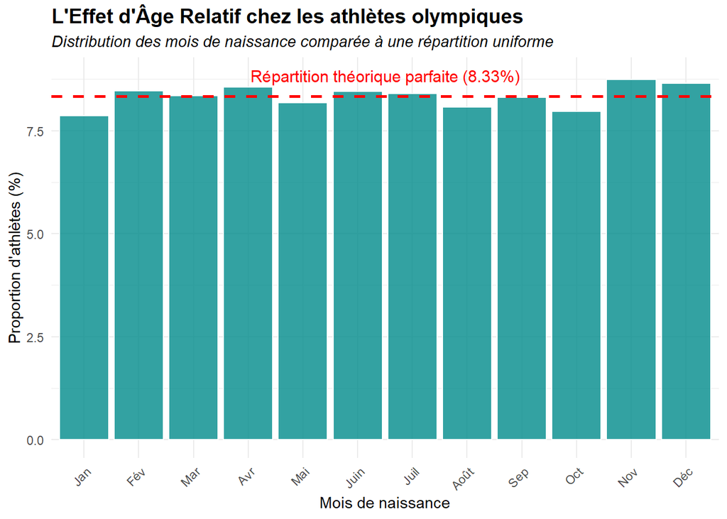

#### Interprétation :

Si la ligne de tendance théorique (en rouge) était parfaitement respectée, chaque mois regrouperait environ 8.33% des naissances. En observant la répartition réelle via les barres du graphique, on peut voir si les mois de début d’année (Janvier, Février, Mars) dépassent cette ligne rouge de manière significative. Le cas échéant, cela confirmera que la sélection précoce dans les filières sportives durant l’enfance offre un avantage mesurable et durable aux enfants nés en début d’année, avantage qui se répercute jusqu’aux Jeux Olympiques.

### Dans quels sports cet effet est-il le plus marqué ?

Pour aller plus loin, nous pouvons identifier les disciplines où ce phénomène est le plus prononcé. L’hypothèse est que les sports nécessitant une grande maturité physique précoce (puissance, vitesse, taille) afficheront un effet d’âge relatif plus fort que les sports de pure technique.

Nous allons calculer le pourcentage d’athlètes nés au premier trimestre (Janvier, Février, Mars) par sport. Théoriquement, si la naissance n’avait aucune influence, ce chiffre devrait être autour de **25%** (3 mois sur 12).

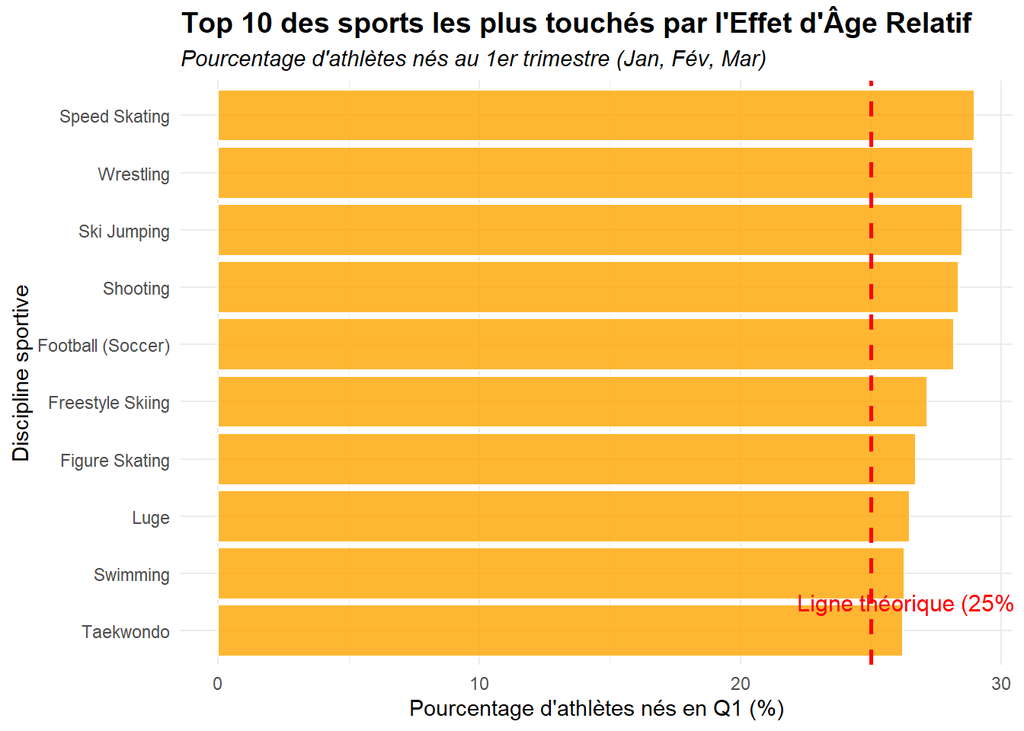

# Question 13 : Sports d’équipe vs Sports individuels : l’âge de l’or

Dans cette partie, nous cherchons à savoir si la dynamique d’équipe influe sur la longévité de la performance au plus haut niveau (la médaille d’or). L’âge de la performance maximale diffère-t-il selon que le sport se pratique seul ou en équipe ?

**Hypothèse :** L’âge médian des médaillés d’or est plus élevé dans les sports d’équipe (Team). L’intelligence tactique, l’expérience et la cohésion de groupe permettent de compenser le léger déclin physique lié à l’âge, là où l’explosivité pure prime davantage dans les sports individuels (Individual).

Pour le vérifier, nous isolons tous les athlètes ayant remporté l’Or et comparons la distribution de leur âge selon la nature de leur épreuve (Individuelle ou Équipe).

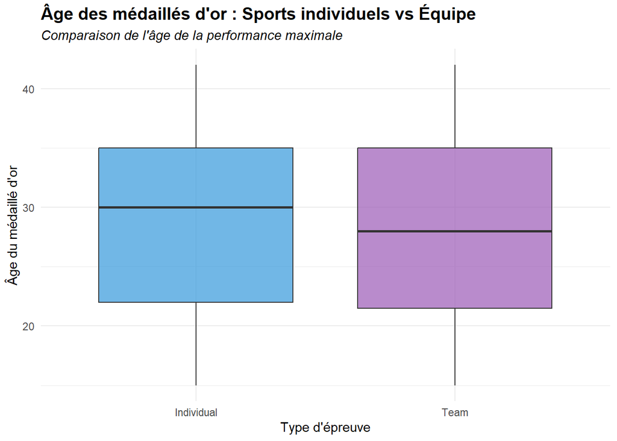

#### Interprétation :

Le graphique contredit notre hypothèse de départ de manière assez surprenante !

En lisant la médiane (la ligne noire épaisse au milieu de chaque boîte), on constate que l’âge médian des médaillés d’or individuels est de **30 ans**, contre environ **28 ans** pour les sports d’équipe.

Comment expliquer cela ? Les sports individuels incluent un grand nombre de disciplines où l’adresse, la précision et la technique priment sur l’explosivité physique pure (le tir, l’équitation, la voile, le golf, etc.), ce qui permet des carrières parfois très longues. À l’inverse, la majorité des sports d’équipe olympiques (comme le football, le basketball, le handball) exigent un engagement athlétique et cardiovasculaire intense, favorisant des athlètes légèrement plus jeunes dans la force de l’âge physique.

Les boîtes (l’écart interquartile) montrent également que la grande majorité des vainqueurs se situent entre 22 et 35 ans dans les deux catégories, démontrant que la performance olympique maximale culmine globalement dans cette fenêtre, mais avec une “prime à l’expérience” paradoxalement plus forte en individuel.

## Question 14 — Les athlètes ayant la plus grande longévité sont-ils aussi ceux qui ont participé à la plus grande diversité d’épreuves ?

### Hypothèse

On suppose que les athlètes les plus polyvalents, c’est-à-dire ceux qui participent à plusieurs sports ou épreuves, peuvent avoir une carrière plus longue.

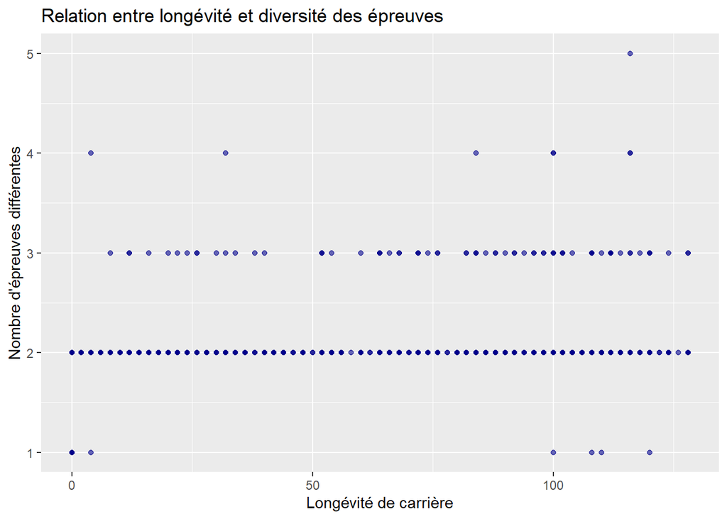

### Choix du graphique

Nous avons choisi un nuage de points car il permet d’étudier la relation entre deux variables quantitatives : la longévité de carrière et le nombre d’épreuves différentes pratiquées. Chaque point représente un athlète.

### Interprétation

Ce graphique permet de voir si les athlètes ayant une carrière plus longue participent aussi à un plus grand nombre d’épreuves. Si les points montent lorsque la longévité augmente, cela indiquerait une relation positive entre polyvalence et durée de carrière.

À l’inverse, si les points sont dispersés sans tendance claire, cela signifie que la longévité ne dépend pas forcément du nombre d’épreuves pratiquées. Dans ce cas, certains athlètes peuvent avoir une longue carrière tout en restant spécialisés dans une seule discipline.

### Conclusion

Ce graphique permet de tester l’hypothèse selon laquelle la polyvalence favorise une carrière plus longue. Il met en relation la durée de carrière des athlètes avec leur diversité d’épreuves, afin de voir si les athlètes les plus polyvalents sont aussi ceux qui restent le plus longtemps dans les Jeux olympiques.

## Question 15 — L’écart-type de la taille des athlètes au sein d’une même discipline a-t-il diminué entre 1924 et 2024 ?

### Hypothèse

Nous supposons qu’au fil du temps, les athlètes d’une même discipline ont développé des caractéristiques physiques de plus en plus similaires. Cette évolution traduirait une spécialisation progressive vers un profil physique considéré comme optimal pour chaque sport.

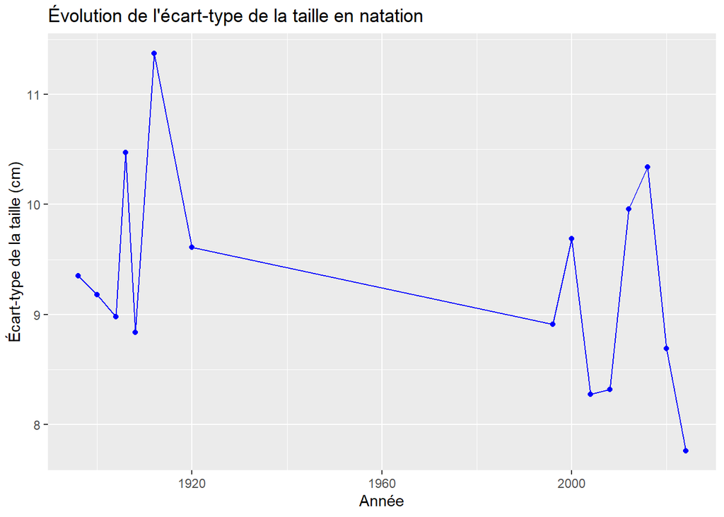

### Choix du graphique

Nous avons choisi un graphique en lignes car nous souhaitons observer l’évolution d’une variable au cours du temps. Ce type de représentation permet de visualiser facilement les tendances et les variations de l’écart-type de la taille des athlètes d’une même discipline.

### Interprétation

Chaque point représente l’écart-type de la taille des nageurs pour une année donnée. L’écart-type mesure la dispersion des tailles autour de la moyenne.

Si la courbe diminue progressivement au fil du temps, cela signifie que les tailles des athlètes deviennent plus homogènes. Cette évolution soutiendrait l’hypothèse d’une standardisation physique, où les sportifs tendent à se rapprocher d’un profil considéré comme optimal pour la discipline.

À l’inverse, si l’écart-type reste stable ou augmente, cela suggère que la diversité physique demeure importante et que plusieurs profils morphologiques peuvent coexister au sein du même sport.

### Conclusion

Cette analyse permet d’étudier l’évolution de la diversité physique des athlètes au sein d’une même discipline. Une diminution de l’écart-type de la taille au cours du temps constituerait un indice de spécialisation progressive des profils physiques.

## Question 16 — La taille des athlètes influence-t-elle davantage les performances mesurées en distance (mètres) que celles mesurées en temps (secondes) ?

### Hypothèse

Nous supposons que la taille constitue un avantage plus important dans les disciplines où la performance est mesurée en distance. Des membres plus longs peuvent favoriser certaines actions comme les lancers ou les sauts.

À l’inverse, dans les disciplines chronométrées, la performance dépend davantage de facteurs tels que la vitesse, l’endurance ou la technique. L’influence directe de la taille pourrait donc être moins marquée.

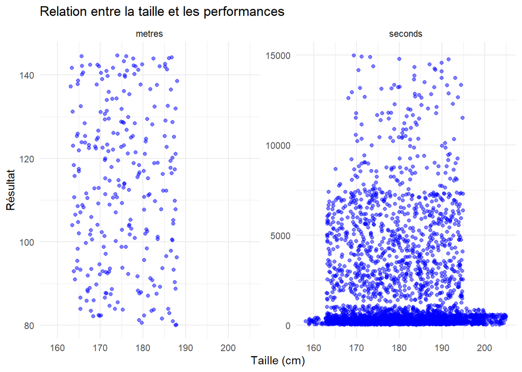

### Choix du graphique

Nous avons choisi un nuage de points car il permet d’étudier la relation entre deux variables quantitatives : la taille des athlètes et leur performance. Le graphique est divisé en deux parties selon l’unité de mesure du résultat (« metres » ou « seconds »). Cette séparation permet de comparer visuellement l’effet de la taille dans différents types d’épreuves.

## Interprétation

Chaque point représente un athlète. L’axe horizontal correspond à sa taille et l’axe vertical à sa performance. Dans les épreuves mesurées en mètres, une tendance croissante entre la taille et le résultat pourrait indiquer qu’une plus grande taille favorise la performance. Cela peut s’expliquer par un avantage biomécanique dans certaines disciplines. Dans les épreuves mesurées en secondes, la relation peut être différente. Une dispersion importante des points ou l’absence de tendance visible suggérerait que la taille n’est pas le principal facteur expliquant la performance. La comparaison des deux graphiques permet ainsi de déterminer si l’influence de la taille est plus forte dans les disciplines de distance que dans les disciplines chronométrées.

## Question 17 — Existe-t-il une corrélation visuelle entre la taille et le poids des athlètes, toutes disciplines confondues ?

## Hypothèse

Nous supposons qu’il existe une corrélation positive entre la taille et le poids des athlètes. En général, les athlètes les plus grands ont également tendance à être plus lourds.

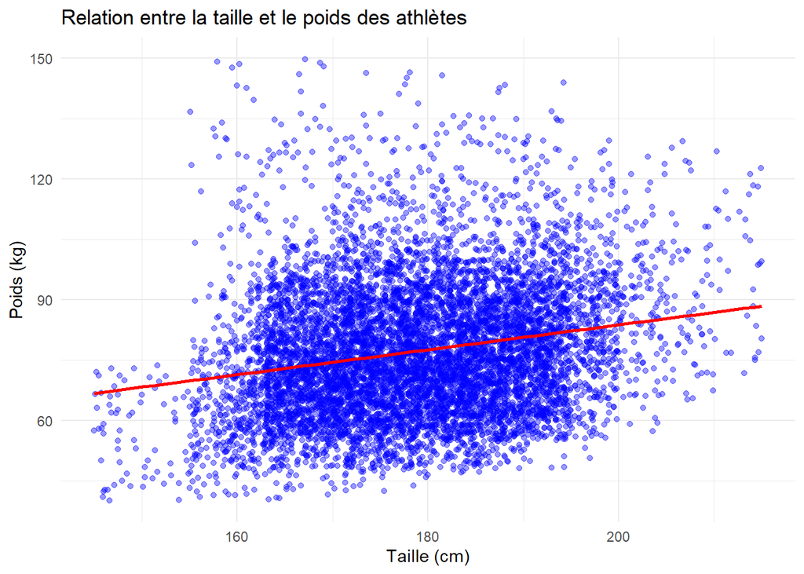

### Choix du graphique

Nous avons choisi un nuage de points car il permet de représenter la relation entre deux variables quantitatives : la taille et le poids. L’ajout d’une ligne de tendance linéaire facilite l’identification d’une corrélation générale entre ces deux caractéristiques physiques.

## Interprétation

Chaque point représente un athlète. L’axe horizontal correspond à sa taille et l’axe vertical à son poids. Si les points suivent globalement une trajectoire ascendante et que la ligne de tendance est croissante, cela indique une corrélation positive entre la taille et le poids. Les athlètes les plus grands ont alors tendance à être également les plus lourds. Le nuage de points permet également d’identifier des valeurs atypiques. Par exemple, un athlète très grand mais extrêmement léger, ou inversement très petit mais particulièrement lourd, apparaîtrait éloigné du reste des observations.

# Question 18 — Combien d’athlètes participent aux Jeux Olympiques d’Été par rapport aux Jeux Olympiques d’Hiver ?

## Hypothèse

Nous supposons que les Jeux Olympiques d’Été rassemblent un plus grand nombre d’athlètes que les Jeux Olympiques d’Hiver.

Cette différence s’explique par le nombre plus élevé de disciplines sportives présentes aux Jeux d’Été ainsi que par la participation d’un plus grand nombre de pays.

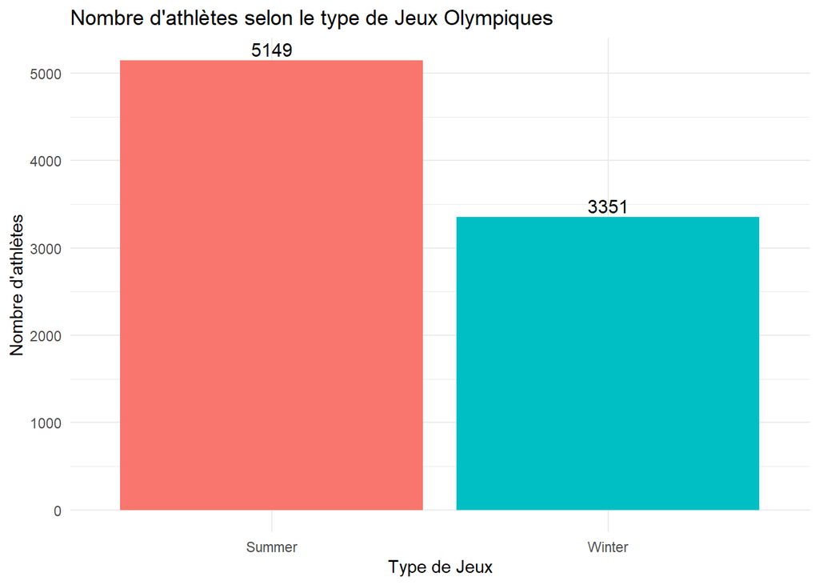

### Choix du graphique

Nous avons choisi un diagramme en barres car il permet de comparer facilement les effectifs de deux catégories distinctes : les Jeux d’Été et les Jeux d’Hiver.

Ce type de représentation rend immédiatement visible la différence d’envergure entre les deux compétitions.

## Interprétation

Chaque barre représente le nombre total d’athlètes participant à un type de Jeux Olympiques.

La comparaison des hauteurs de barres permet d’observer immédiatement quelle compétition rassemble le plus grand nombre d’athlètes.

Si la barre correspondant aux Jeux d’Été est nettement plus élevée, cela confirme que cette compétition possède une envergure plus importante en termes de participation.

# Question 19 : Chaque discipline possède-t-elle une « empreinte morphologique » qui lui est propre ?

La Question 17 a montré une corrélation globale entre la taille et le poids des athlètes, toutes disciplines confondues. Mais cette nuée de points globale cache peut-être plusieurs *sous-populations* : un basketteur et un gymnaste n’ont rien à voir physiquement. Nous cherchons donc ici à savoir si chaque discipline occupe une **zone distincte** du plan taille × poids, formant une véritable « empreinte morphologique ».

**Hypothèse :** chaque discipline impose des contraintes physiques spécifiques. On devrait donc observer des nuages de densité nettement séparés (les basketteurs grands et lourds, les gymnastes petits et légers, les haltérophiles courts mais très massifs, etc.).

### Choix du graphique

Pour répondre, un simple nuage de points serait illisible (8500 points superposés). Nous utilisons donc une **carte de densité 2D** (`geom_density_2d_filled`) : au lieu d’afficher chaque athlète, elle colorie les zones du plan selon la *concentration* d’athlètes. Plus une zone est claire, plus les athlètes y sont nombreux. En affichant une facette par discipline, on compare directement les « empreintes » côte à côte. Nous complétons par une seconde vue où toutes les disciplines sont superposées sur un même plan, avec une **ellipse de confiance à 95 %** par discipline, qui résume d’un seul trait la zone occupée par chaque sport.

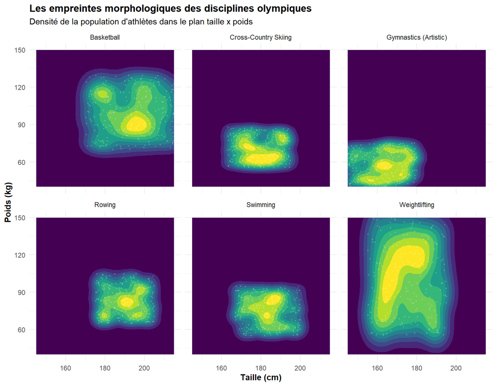

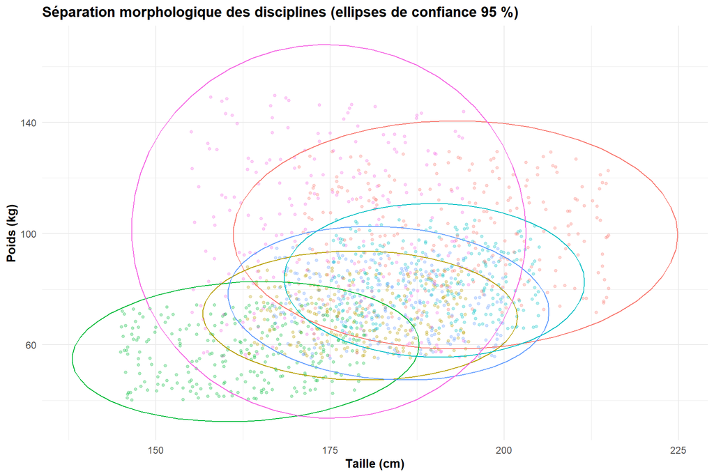

### Interprétation

- La **Gymnastique (Artistique)** forme une tache compacte en bas à gauche : athlètes petits (≈ 163 cm) et légers (≈ 58 kg), profil idéal pour les figures acrobatiques.
- Le **Basketball** se situe à l’opposé, en haut à droite : grands (≈ 193 cm) et lourds (≈ 100 kg).
- L’**Aviron (Rowing)** et la **Natation (Swimming)** dessinent des nuages allongés de grande taille mais de poids modéré (gabarits longs et secs).
- L’**Haltérophilie (Weightlifting)** est remarquable : taille moyenne (≈ 175 cm) mais poids extrêmement variable (jusqu’à ~150 kg), d’où une empreinte très étirée verticalement — reflet des catégories de poids, des poids plumes aux super-lourds.
- Le **Ski de fond (Cross-Country Skiing)** occupe une zone d’endurance : gabarit intermédiaire et resserré.

### Conclusion

La densité 2D s’avère bien plus parlante qu’un nuage de points classique : elle révèle que la question « quelle est la morphologie d’un athlète olympique ? » n’a pas de réponse unique, mais une réponse **par discipline**. Cela ouvre naturellement la question suivante : peut-on résumer ces gabarits par un indicateur unique, l’IMC, et classer les disciplines de la plus « légère » à la plus « lourde » ?

# Question 20 : Peut-on classer les disciplines selon un « gabarit type » mesuré par l’IMC ?

La Question 19 a montré des empreintes morphologiques distinctes. Nous proposons ici de les **résumer par un seul indicateur**, l’Indice de Masse Corporelle (IMC = poids / taille²), et de **classer les 33 disciplines** du gabarit le plus léger au plus lourd.

**Hypothèse :** les sports de saut, de glisse et d’esthétique (saut à ski, gymnastique, cyclisme) afficheront un IMC faible, tandis que les sports de force pure (haltérophilie, lutte) afficheront un IMC très élevé. Nous nous attendons à un classement progressif et cohérent.

### Choix du graphique

[figure not shown]

### Interprétation

L’écart entre les deux extrêmes est considérable (≈ 14 points d’IMC), ce qui montre à quel point les exigences physiques diffèrent d’un sport à l’autre.

### Conclusion

L’IMC se révèle un excellent indicateur synthétique pour « cartographier » les disciplines : il résume en une dimension ce que la Question 19 montrait en deux. Après avoir épuisé l’angle *morphologique*, nous changeons d’échelle pour nous intéresser non plus à l’athlète, mais à la **nation** : l’histoire et le rang d’un pays expliquent-ils son palmarès ?

# Question 21 : L’ancienneté olympique et le rang historique d’une nation prédisent-ils son palmarès ?

Nous quittons l’athlète pour la **nation**. Le jeu de données contient des agrégats par pays : l’année de première participation (`country_first_participation`), le total historique de médailles (`country_total_medals`) et le meilleur classement jamais atteint (`country_best_rank`). Nous nous demandons si ces variables sont liées : **un pays présent depuis longtemps, ou très bien classé, gagne-t-il davantage de médailles ?**

**Hypothèse :** les nations historiques (présentes dès 1896) et celles ayant déjà atteint le sommet du classement (rang 1) ont accumulé un palmarès bien supérieur. Nous anticipons une corrélation négative entre l’année de première participation et le total de médailles (plus on arrive tôt, plus on accumule), et une corrélation négative entre le meilleur rang et le total (meilleur rang = chiffre plus petit = plus de médailles).

### Choix du graphique

Les agrégats `country_*` ne prennent **qu’une seule valeur par pays** : nous réduisons donc le jeu de données à une ligne par pays. Nous traçons ensuite deux **nuages de points** avec une **droite de régression linéaire** (`geom_smooth(method = "lm")`) pour matérialiser la tendance. Comme le total de médailles varie énormément (de 5 à plus de 2600), nous passons l’axe vertical en **échelle logarithmique** pour rendre le graphique lisible. Quelques pays remarquables sont annotés.

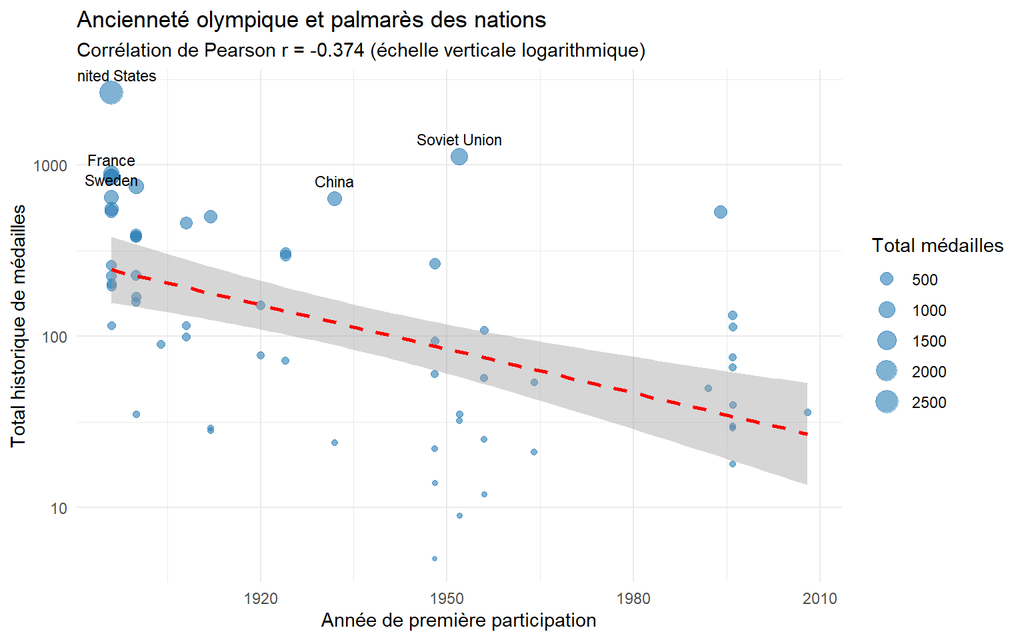

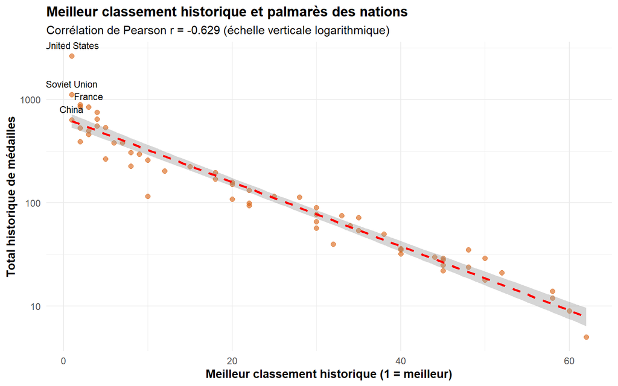

### Interprétation

Les deux panneaux valident notre hypothèse, avec des forces différentes :

- **Ancienneté (r ≈ -0,37) :** la tendance est réelle mais modérée. Les nations fondatrices (États-Unis, France, Grande-Bretagne, Allemagne, toutes présentes dès 1896) figurent bien parmi les plus médaillées. Mais la corrélation est loin d’être parfaite : la **Chine** (1ère participation en 1932) et l’**Union soviétique** (1952) sont arrivées tardivement tout en figurant parmi les toutes premières nations du palmarès. L’ancienneté aide, mais la puissance démographique et l’investissement comptent davantage.
- **Meilleur rang (r ≈ -0,63) :** la corrélation est nettement plus forte. Avoir déjà atteint le rang 1 va presque systématiquement de pair avec un énorme total de médailles. C’est logique : il s’agit de deux mesures de la même domination sportive.

L’échelle logarithmique est ici indispensable : sans elle, les États-Unis (≈ 2638 médailles) écraseraient à eux seuls tout le graphique.

### Conclusion

Le rang historique est un bien meilleur prédicteur du palmarès que la simple ancienneté. Mais toutes les médailles ne se valent pas : un pays peut accumuler beaucoup de podiums sans dominer. La dernière question affine donc l’analyse en s’intéressant à la **qualité** du palmarès - la part d’or.